# AI ANALYST LAB

[figure not shown]

### A Hands-on Course on AI for Data Analysts

## Session 08: Decision trees for regression and classification

Feedback should be sent to goran.milovanovic@datakolektiv.com.

This notebook accompanies the **AI Analyst LAB** course. Welcome to Session 08 — the **final, capstone session**. Everything you have built across the course comes together here: a model you can *explain*, a set of rules a manager can *act on*, and an AI-assisted report that turns your computed results into a stakeholder-ready summary.

### What we will do today

Most machine-learning models are black boxes: they give an answer but cannot tell you *why*. **Decision trees** are the great exception — they are just a flowchart of yes/no questions, and their logic reads like plain English. That makes them the perfect capstone: powerful enough to be useful, transparent enough to hand to a non-technical leader.

| Section | What happens |
| --- | --- |
| 8.1–8.3 | The business case, your tutor, and setup |
| 8.4–8.6 | The idea: entropy (a reminder), what a tree is, and **information gain** — how a tree decides where to split |
| 8.7 | A first classification tree, on the Titanic |
| 8.8 | A classification tree on our data — Iranian Churn |
| 8.9 | Overfitting, and how to tame it |
| 8.10–8.11 | **Regression** trees — the idea, and one on our Wine Quality data |
| 8.12 | Turning a tree into a decision policy leadership can read |
| 8.13–8.14 | The capstone: an **AI-assisted analytics report** (schema-based) |
| 8.15–8.16 | References, and a look back over the whole course |

As always: **Python computes the numbers; we read them honestly.**

## 8.1 The business case

Imagine leadership at **CityCycle** (Session 01), or the telecom from Session 05, asks you a very reasonable question:

> *"Your churn model is 91% accurate — great. But **why** does it flag a customer? I'm not signing off on a black box. Give me rules my team can actually follow."*

This is the everyday reality of analytics: many business teams *prefer* simple, auditable **"if-then" logic** they can understand and defend — over a more accurate model they cannot explain. Decision trees are the gateway to exactly that: interpretable decision-making, and, not coincidentally, the foundation of many modern methods (random forests, gradient boosting). This session is about **usable rules, not black-box mystique**.

## 8.2 Meet your Session 08 Tutor

Before you continue, set up your **Session 08 Tutor** — a Claude Project configured to teach the ideas behind this notebook (entropy and information gain, how trees split, overfitting, regression vs classification) in a gentle, beginner-friendly way.

If you have not done this yet, open **`_tutors/session08_tutor.xml`** and follow the setup steps in **`_tutors/TutorProjectCreation.md`**. It takes about two minutes. Whenever a line in this notebook feels unclear, paste it into the tutor and ask *"what does this mean?"*

## 8.3 Setup — the tools we need

Trees, and everything around them, live in **scikit-learn** — the same library we have used since Session 00. We import the tree models, a train/test splitter, and a few metrics.

```python
# pandas for tables, numpy for arrays, matplotlib for plots — our usual trio.
import json                      # used later to hand our computed numbers to the API
import numpy as np
import pandas as pd
import matplotlib.pyplot as plt

# scikit-learn: the two tree models, plus tools to draw and read them.
from sklearn.tree import (
    DecisionTreeClassifier, DecisionTreeRegressor, plot_tree, export_text
)
# Splitting data into train/test, and metrics to score our models.
from sklearn.model_selection import train_test_split
from sklearn.metrics import (
    accuracy_score, confusion_matrix, mean_absolute_error, r2_score
)

# Markdown and display let us render rich Markdown output directly in the notebook.
from IPython.display import Markdown, display

# Keep the notebook output clean.
import warnings
warnings.filterwarnings("ignore")

print("Tools ready. scikit-learn tree models loaded.")
```

```
Tools ready. scikit-learn tree models loaded.
```

## 8.4 A reminder from Review 03 — entropy is *uncertainty*

Session 08 leans on one idea from **Review 03 (Information Theory)**: **entropy**. You do not need to re-read the whole review, just to recall the intuition, because it is the engine inside every classification tree.

[figure not shown]

The picture says it all. We want to predict the next ball drawn from an urn. **Urn A** is 8 black to 2 white — fairly predictable, *low* uncertainty. **Urn B** is 5 black to 5 white — a coin toss, *maximum* uncertainty. **Entropy** is simply the number that measures this: **low when a group is "pure" (mostly one class), high when it is a mixed 50/50 muddle.**

Here is entropy computed directly from a list of labels — exactly the Review 03 formula $H = -\sum_i p_i \log_2 p_i$, now reading the probabilities straight off the data:

```python
def entropy(labels):
    # Shannon entropy (in bits) of a set of class labels.
    labels = np.asarray(labels)
    _, counts = np.unique(labels, return_counts=True)
    p = counts / counts.sum()          # the proportion of each class
    return float(-np.sum(p * np.log2(p)))

# Urn A (8 black, 2 white) vs Urn B (5 black, 5 white):
urn_a = ["black"] * 8 + ["white"] * 2
urn_b = ["black"] * 5 + ["white"] * 5
print("Urn A  (8:2)  entropy =", round(entropy(urn_a), 3), "bits   <- more predictable")
print("Urn B  (5:5)  entropy =", round(entropy(urn_b), 3), "bits   <- maximally uncertain")
# A perfectly pure group has zero entropy:
print("Pure   (10:0) entropy =", round(entropy(["black"] * 10), 3), "bits   <- no uncertainty at all")
```

```
Urn A  (8:2)  entropy = 0.722 bits   <- more predictable
Urn B  (5:5)  entropy = 1.0 bits   <- maximally uncertain
Pure   (10:0) entropy = -0.0 bits   <- no uncertainty at all
```

## 8.5 What is a decision tree?

A **decision tree** is a flowchart of yes/no questions. You start at the top, answer one question at a time, and follow the branches down until you reach a **leaf** that gives you a prediction. Here is a toy tree for *"should I buy this used car?"*:

[figure not shown]

Three pieces of vocabulary, and that is the whole model:

- **Root node** (top): the first question asked of every case — here, *"Red car?"*
- **Internal nodes**: further questions that narrow things down — *"Model > 2010?"*, *"Mileage > 50 000 km?"*
- **Leaves** (bottom): the final answers — *Buy* / *Don't buy*.

Every path from the root to a leaf is a plain-English **if-then rule**: *"IF the car is red AND newer than 2010, THEN buy."* That readability is the entire point. The only real question left is: **how does the tree decide which question to ask, and in what order?** That is where entropy comes back.

## 8.6 How a tree chooses a split — Information Gain

A tree builds itself **greedily**: at every node it tries all possible questions and picks the one that makes the resulting groups **as pure as possible**. "Pure" means low entropy. The improvement a split gives us has a name — **Information Gain**:

$$\text{Information Gain} = \underbrace{H(\text{parent})}_{\text{uncertainty before}} \;-\; \underbrace{\left[\, w_L\,H(\text{left}) + w_R\,H(\text{right}) \,\right]}_{\text{average uncertainty after}}$$

where $w_L, w_R$ are the *fractions* of cases sent left and right. In words: **information gain is how many bits of uncertainty a question removes.** The tree simply asks the question with the biggest information gain, then repeats on each child.

Let's compute it by hand on a tiny example. Suppose 10 customers, 5 churned and 5 stayed — a maximally uncertain parent (1 bit). We test the split *"Did the customer complain?"*:

```python
def information_gain(parent, left, right):
    # Bits of uncertainty removed by splitting `parent` into `left` and `right`.
    n = len(parent)
    w_left, w_right = len(left) / n, len(right) / n
    after = w_left * entropy(left) + w_right * entropy(right)
    return entropy(parent) - after

# 10 customers: 5 churn, 5 stay.
parent = ["churn"] * 5 + ["stay"] * 5

# Split on "complained?": complainers are almost all churners; non-complainers almost all stay.
complained     = ["churn"] * 4 + ["stay"] * 1     # 5 who complained
not_complained = ["churn"] * 1 + ["stay"] * 4     # 5 who did not

print("parent entropy         :", round(entropy(parent), 3), "bits")
print("left  (complained)     :", round(entropy(complained), 3), "bits")
print("right (did not)        :", round(entropy(not_complained), 3), "bits")
print("-> Information Gain     :", round(information_gain(parent, complained, not_complained), 3), "bits")
```

```
parent entropy         : 1.0 bits
left  (complained)     : 0.722 bits
right (did not)        : 0.722 bits
-> Information Gain     : 0.278 bits
```

The split removed a big chunk of uncertainty, so *"Did the customer complain?"* is a **good question** — a tree would love it. A useless split (one that leaves both groups just as mixed as before) would score an information gain near **zero**.

**One alternative worth knowing: Gini impurity.** scikit-learn's *default* split criterion is not entropy but **Gini impurity**, $\;G = 1 - \sum_i p_i^2$. It measures the same thing — how mixed a group is — and almost always produces near-identical trees. Entropy and Gini are two rulers for the same quantity; use whichever you like.

```python
def gini(labels):
    # Gini impurity: another measure of how "mixed" a set of labels is.
    labels = np.asarray(labels)
    _, counts = np.unique(labels, return_counts=True)
    p = counts / counts.sum()
    return float(1 - np.sum(p ** 2))

for group, name in [(urn_a, "Urn A (8:2)"), (urn_b, "Urn B (5:5)")]:
    print(f"{name:12s}  entropy = {entropy(group):.3f} bits   gini = {gini(group):.3f}")
```

```
Urn A (8:2)   entropy = 0.722 bits   gini = 0.320
Urn B (5:5)   entropy = 1.000 bits   gini = 0.500
```

## 8.7 A first classification tree — the Titanic

Time to let scikit-learn build a real tree. We start with the **Titanic** dataset — a small, intuitive problem where the rules read like history. We predict whether a passenger **survived** from three facts: their **passenger class**, their **sex**, and their **age**.

*(The Titanic set is our warm-up demo; from §8.8 onward we switch to the course's own business datasets.)*

```python
# Load the Titanic training data and keep the four columns we need.
titanic = pd.read_csv("../_data/titanic/Titanic_train.csv")[["Survived", "Pclass", "Sex", "Age"]]

# Age has some missing values; for this gentle demo we simply drop those rows.
titanic = titanic.dropna().reset_index(drop=True)

# A tree needs numbers, so encode Sex: female = 1, male = 0.
titanic["Sex"] = (titanic["Sex"] == "female").astype(int)

print("shape after cleaning:", titanic.shape)
titanic.head()
```

```
shape after cleaning: (714, 4)
```

|  | Survived | Pclass | Sex | Age |
| --- | --- | --- | --- | --- |
| 0 | 0 | 3 | 0 | 22.0 |
| 1 | 1 | 1 | 1 | 38.0 |
| 2 | 1 | 3 | 1 | 26.0 |
| 3 | 1 | 1 | 1 | 35.0 |
| 4 | 0 | 3 | 0 | 35.0 |

We split into a **training set** (to build the tree) and a **test set** (to check it on data it has never seen — the honest measure of a model). Then we fit a shallow tree, `max_depth=3`, so it stays readable.

```python
features = ["Pclass", "Sex", "Age"]
X = titanic[features]
y = titanic["Survived"]

# 70% to train on, 30% held back to test honestly.
X_train, X_test, y_train, y_test = train_test_split(X, y, test_size=0.3, random_state=42)

# Build a shallow classification tree, using entropy (information gain) to choose splits.
clf = DecisionTreeClassifier(max_depth=3, criterion="entropy", random_state=42)
clf.fit(X_train, y_train)

# How accurate is it on the held-back test set?
acc = accuracy_score(y_test, clf.predict(X_test))
print(f"Test accuracy: {acc:.1%}")
```

```
Test accuracy: 76.3%
```

Now the payoff — we can **look inside**. `plot_tree` draws the whole model. Read it top-down: each box shows the question, the entropy, how many passengers reached it, and the class split.

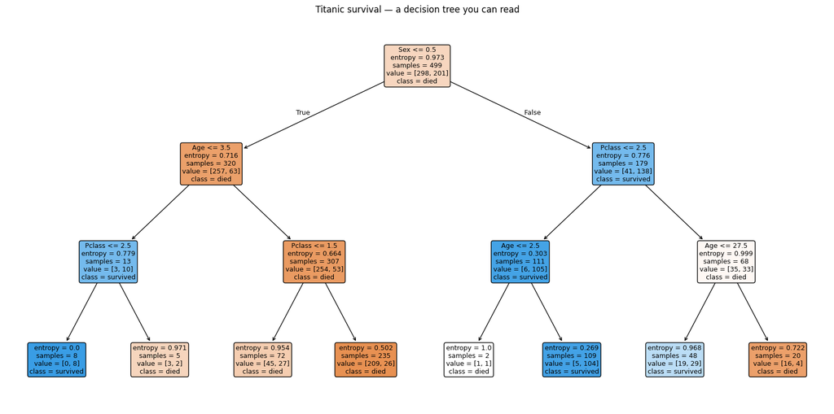

```python
plt.figure(figsize=(16, 8))
plot_tree(
    clf, feature_names=features, class_names=["died", "survived"],
    filled=True, rounded=True, fontsize=9, impurity=True,
)
plt.title("Titanic survival — a decision tree you can read")
plt.tight_layout()
plt.show()
```

The very first split the tree chooses is **Sex** — because it delivers the most information gain (the grim historical "women and children first"). That single, data-driven choice matches what any historian would tell you, and we never hard-coded it. We can also print the tree as literal **if-then rules**:

```python
print(export_text(clf, feature_names=features))
```

```
|--- Sex <= 0.50
|   |--- Age <= 3.50
|   |   |--- Pclass <= 2.50
|   |   |   |--- class: 1
|   |   |--- Pclass >  2.50
|   |   |   |--- class: 0
|   |--- Age >  3.50
|   |   |--- Pclass <= 1.50
|   |   |   |--- class: 0
|   |   |--- Pclass >  1.50
|   |   |   |--- class: 0
|--- Sex >  0.50
|   |--- Pclass <= 2.50
|   |   |--- Age <= 2.50
|   |   |   |--- class: 0
|   |   |--- Age >  2.50
|   |   |   |--- class: 1
|   |--- Pclass >  2.50
|   |   |--- Age <= 27.50
|   |   |   |--- class: 1
|   |   |--- Age >  27.50
|   |   |   |--- class: 0
```

## 8.8 A classification tree on our data — Iranian Churn

Now we return to a **course dataset**: the **Iranian Churn** data from Session 05. The task is the one leadership actually cares about — predict which customers will **churn** — but this time with a model whose reasoning we can hand over as rules.

```python
churn = pd.read_csv("../_data/iranian_churn/Customer Churn.csv")
# The raw column names contain stray double spaces — tidy them up.
churn.columns = [c.strip().replace("  ", " ") for c in churn.columns]

y = churn["Churn"]                       # 1 = churned, 0 = stayed
X = churn.drop(columns=["Churn"])

print("customers:", len(churn), "| features:", X.shape[1], "| churn rate:", round(y.mean(), 3))
X.columns.tolist()
```

```
customers: 3150 | features: 13 | churn rate: 0.157
```

```
['Call Failure',
 'Complains',
 'Subscription Length',
 'Charge Amount',
 'Seconds of Use',
 'Frequency of use',
 'Frequency of SMS',
 'Distinct Called Numbers',
 'Age Group',
 'Tariff Plan',
 'Status',
 'Age',
 'Customer Value']
```

We train a slightly deeper tree (`max_depth=4`) and, because churn is imbalanced, we **stratify** the split so train and test keep the same churn rate.

```python
X_train, X_test, y_train, y_test = train_test_split(
    X, y, test_size=0.3, random_state=42, stratify=y
)
churn_tree = DecisionTreeClassifier(max_depth=4, criterion="entropy", random_state=42)
churn_tree.fit(X_train, y_train)

pred = churn_tree.predict(X_test)
print(f"Test accuracy: {accuracy_score(y_test, pred):.1%}")
```

```
Test accuracy: 90.7%
```

Accuracy alone can mislead when classes are imbalanced (Session 05's lesson), so we read the **confusion matrix** — how many churners we caught vs missed, and how many false alarms we raised.

```python
cm = confusion_matrix(y_test, pred)
cm_df = pd.DataFrame(cm,
    index=["actual: stay", "actual: churn"],
    columns=["predicted: stay", "predicted: churn"])
print(cm_df)
```

```
               predicted: stay  predicted: churn
actual: stay               764                33
actual: churn               55                93
```

Which features does the tree lean on most? `feature_importances_` ranks them by how much total information gain each contributed — a ready-made "what drives churn" list:

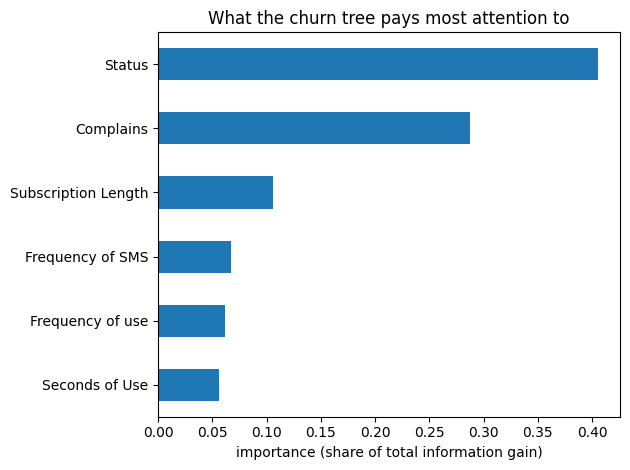

```python
importances = (pd.Series(churn_tree.feature_importances_, index=X.columns)
               .sort_values(ascending=False))
importances.head(6).plot.barh(color="#1f77b4")
plt.gca().invert_yaxis()
plt.title("What the churn tree pays most attention to")
plt.xlabel("importance (share of total information gain)")
plt.tight_layout()
plt.show()
```

## 8.9 Overfitting — and how to tame it

A tree left to grow without limits will keep splitting until every leaf is perfectly pure — it will **memorise** the training data, quirks and noise included. That is **overfitting**: dazzling on data it has seen, unreliable on data it has not. The tell-tale sign is a big gap between **training** accuracy and **test** accuracy.

Let's grow an unrestricted tree and watch the gap appear:

```python
deep = DecisionTreeClassifier(criterion="entropy", random_state=42)   # no depth limit
deep.fit(X_train, y_train)
print(f"Unlimited tree — train accuracy: {accuracy_score(y_train, deep.predict(X_train)):.1%}")
print(f"Unlimited tree — test  accuracy: {accuracy_score(y_test,  deep.predict(X_test)):.1%}")
print(f"depth actually reached: {deep.get_depth()},  leaves: {deep.get_n_leaves()}")
```

```
Unlimited tree — train accuracy: 99.3%
Unlimited tree — test  accuracy: 94.9%
depth actually reached: 16,  leaves: 97
```

Near-perfect on training data, noticeably worse on test data — the classic overfitting fingerprint. The cure is to **limit the tree's complexity**. The main dials:

- **`max_depth`** — how many questions deep the tree may go.
- **`min_samples_leaf`** — refuse to create a leaf with too few customers in it.
- **`ccp_alpha`** — *cost-complexity pruning*: snip back branches that do not earn their keep.

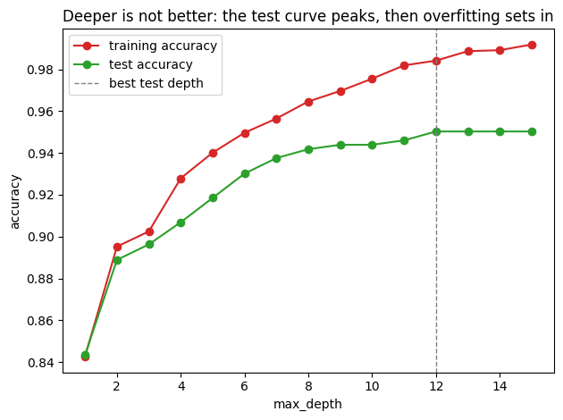

```
Best max_depth by test accuracy: 12
```

```python
depths = range(1, 16)
train_acc, test_acc = [], []
for d in depths:
    m = DecisionTreeClassifier(max_depth=d, criterion="entropy", random_state=42).fit(X_train, y_train)
    train_acc.append(accuracy_score(y_train, m.predict(X_train)))
    test_acc.append(accuracy_score(y_test,  m.predict(X_test)))

plt.plot(list(depths), train_acc, "-o", label="training accuracy", color="#d62728")
plt.plot(list(depths), test_acc,  "-o", label="test accuracy",     color="#2ca02c")
plt.axvline(int(np.argmax(test_acc)) + 1, ls="--", color="grey", lw=1, label="best test depth")
plt.xlabel("max_depth"); plt.ylabel("accuracy")
plt.title("Deeper is not better: the test curve peaks, then overfitting sets in")
plt.legend(); plt.tight_layout(); plt.show()

print("Best max_depth by test accuracy:", int(np.argmax(test_acc)) + 1)
```

## 8.10 Regression trees — predicting a *number*

Everything so far predicted a **category** (survived/died, churn/stay). But trees can just as easily predict a **number** — a price, a demand, a score. That is a **regression tree**, and only two things change:

1. **A leaf predicts the *average* of the training values that land in it** (instead of a majority class).
2. **The split criterion is no longer entropy.** A number has no "classes" to be pure about, so instead we ask each split to **reduce the spread** of the values — measured by variance (mean squared error). A good split produces child groups whose values are tightly clustered. scikit-learn calls this `criterion="squared_error"`.

The *idea* is identical to information gain: pick the question that removes the most uncertainty — we just measure uncertainty as **variance** rather than entropy.

Let's make "reduce the spread" concrete, exactly as we did for information gain in §8.6 — but with numbers instead of classes. We measure a group's spread with its **SSE** (the average squared distance from the group's mean — this is just the variance), and a split's **variance reduction** is the drop in SSE, weighted by group size:

$$\text{Variance reduction} = \underbrace{\text{SSE}(\text{parent})}_{\text{spread before}} \;-\; \underbrace{\left[\, w_L\,\text{SSE}(\text{left}) + w_R\,\text{SSE}(\text{right}) \,\right]}_{\text{average spread after}}$$

It is the **same formula as information gain, with SSE in place of entropy.** Suppose 6 wines with quality scores `[4, 4, 5, 7, 8, 8]`, and a candidate split that sends the three low scores one way and the three high scores the other:

```python
def sse(values):
    # Regression "impurity": the average squared distance from the group's mean (its variance).
    values = np.asarray(values, dtype=float)
    return float(np.mean((values - values.mean()) ** 2))

def variance_reduction(parent, left, right):
    # The regression twin of information_gain: how much a split shrinks the spread.
    n = len(parent)
    after = (len(left) / n) * sse(left) + (len(right) / n) * sse(right)
    return sse(parent) - after

parent = [4, 4, 5, 7, 8, 8]
low    = [4, 4, 5]     # one child group
high   = [7, 8, 8]     # the other child group

print("parent SSE (spread before) :", round(sse(parent), 3))
print("left   SSE (low scores)     :", round(sse(low), 3))
print("right  SSE (high scores)    :", round(sse(high), 3))
print("-> Variance reduction        :", round(variance_reduction(parent, low, high), 3))
```

```
parent SSE (spread before) : 3.0
left   SSE (low scores)     : 0.222
right  SSE (high scores)    : 0.222
-> Variance reduction        : 2.778
```

The split collapses the spread — each child is tightly clustered — so this is a **good** regression split, exactly as a large information gain marked a good *classification* split. Line them up side by side and the symmetry is the whole lesson:

|  | Classification tree | Regression tree |
| --- | --- | --- |
| Measures a group's "mess" with | **entropy** (or Gini) | **SSE** (variance) |
| Picks the split that maximises | **information gain** | **variance reduction** |
| A leaf predicts | the **majority class** | the **average value** |

And that last row is the final piece: a regression leaf simply predicts the **mean** of its group — here, about `4.33` for the low leaf and `7.67` for the high one. That is all a regression tree ever does, all the way down: *keep splitting to shrink the spread, then predict the average at each leaf.*

## 8.11 A regression tree on our data — Wine Quality

We use the **Wine Quality** dataset from Session 04 and predict a wine's **quality score** (roughly 3–8) from its 11 physicochemical measurements — a regression problem, with a tree.

```python
wine = pd.read_csv("../_data/wine_quality/winequality-red.csv", sep=";")
Xw = wine.drop(columns=["quality"])
yw = wine["quality"]

Xw_train, Xw_test, yw_train, yw_test = train_test_split(Xw, yw, test_size=0.3, random_state=42)

# A regression tree: leaves predict a number; splits reduce variance (squared error).
wine_tree = DecisionTreeRegressor(max_depth=4, criterion="squared_error", random_state=42)
wine_tree.fit(Xw_train, yw_train)

pred = wine_tree.predict(Xw_test)
print(f"Mean Absolute Error: {mean_absolute_error(yw_test, pred):.3f} quality points")
print(f"R-squared          : {r2_score(yw_test, pred):.3f}")
```

```
Mean Absolute Error: 0.548 quality points
R-squared          : 0.255
```

`MAE ≈ 0.55` means the tree's quality prediction is off by about half a point on average — a genuinely useful ballpark from a fully transparent model. As before, we can look inside; the top splits reveal which chemistry the tree finds most decisive for quality:

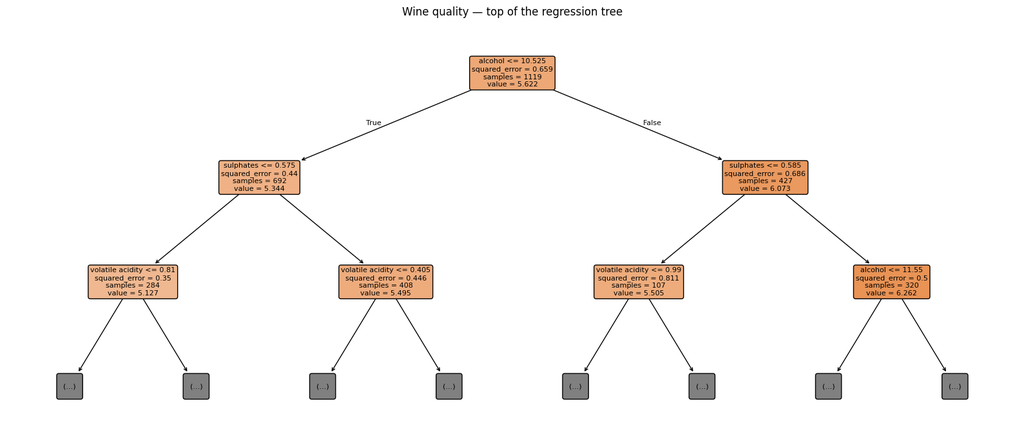

```
Most decisive measurements:
alcohol                 0.518
sulphates               0.231
volatile acidity        0.162
total sulfur dioxide    0.040
dtype: float64
```

```python
plt.figure(figsize=(16, 7))
plot_tree(wine_tree, feature_names=list(Xw.columns), filled=True, rounded=True,
          fontsize=8, max_depth=2)   # show the top 2 levels so it stays legible
plt.title("Wine quality — top of the regression tree")
plt.tight_layout(); plt.show()

print("Most decisive measurements:")
print(pd.Series(wine_tree.feature_importances_, index=Xw.columns)
      .sort_values(ascending=False).head(4).round(3))
```

## 8.12 From tree to decision policy

Here is the moment the whole session has been building toward. A trained tree is not just a predictor — it is a **set of rules you can hand to a manager**. `export_text` writes any tree out as plain if-then logic. We take a deliberately **shallow** churn tree (depth 3) so the policy is short enough to fit on a slide:

```python
policy_tree = DecisionTreeClassifier(max_depth=3, criterion="entropy", random_state=42)
policy_tree.fit(X_train, y_train)

rules = export_text(policy_tree, feature_names=list(X.columns))
print(rules)
```

```
|--- Status <= 1.50
|   |--- Complains <= 0.50
|   |   |--- Frequency of SMS <= 36.50
|   |   |   |--- class: 0
|   |   |--- Frequency of SMS >  36.50
|   |   |   |--- class: 0
|   |--- Complains >  0.50
|   |   |--- Seconds of Use <= 5983.00
|   |   |   |--- class: 1
|   |   |--- Seconds of Use >  5983.00
|   |   |   |--- class: 0
|--- Status >  1.50
|   |--- Complains <= 0.50
|   |   |--- Subscription Length <= 27.50
|   |   |   |--- class: 0
|   |   |--- Subscription Length >  27.50
|   |   |   |--- class: 0
|   |--- Complains >  0.50
|   |   |--- Frequency of use <= 51.50
|   |   |   |--- class: 1
|   |   |--- Frequency of use >  51.50
|   |   |   |--- class: 1
```

## 8.13 The capstone — an AI-assisted analytics report

The final skill of the course: turn your computed results into a **stakeholder-ready report**, with Claude drafting the prose — but only ever from numbers *we* computed. This is the same *"Python computes, the LLM interprets"* discipline from every prior session, now applied to a **model governance report** (a "model card"): what the model is for, what it's good at, and — crucially — its limitations and how to monitor it.

We use **two** calls, exactly as in Sessions 03–07:

1. a **schema-forced tool call** that guarantees a structured report skeleton (via a Pydantic model);
2. a **plain-text call** where a *Model Governance Assistant* writes the summary paragraph.

### Step 1 — verify the API key is available

```python
# [SESSION08-API-CELL: run locally with your own ANTHROPIC_API_KEY]

# Import os so we can read environment variables.
import os

# Read the Anthropic API key from the environment.
anth_key = os.environ.get("ANTHROPIC_API_KEY")

# If the key is missing, halt with a clear, actionable message (do not silently continue).
if not anth_key:
    raise SystemExit(
        "ANTHROPIC_API_KEY is not set in your environment.\n"
        "Follow the 'Set up your Claude API access' steps in the repository README, "
        "restart VS Code, and re-run this cell."
    )
print("ANTHROPIC_API_KEY found.")
```

```
ANTHROPIC_API_KEY found.
```

### Step 2 — create the Anthropic client

```python
# [SESSION08-API-CELL: run locally with your own ANTHROPIC_API_KEY]

# Import the official Anthropic Python SDK and create the client (it reads the key automatically).
import anthropic
client = anthropic.Anthropic()
print("Anthropic client ready.")
```

```
Anthropic client ready.
```

### Step 3 — define a Pydantic schema for the model card

```python
# [SESSION08-API-CELL: run locally with your own ANTHROPIC_API_KEY]

# Pydantic lets us declare the EXACT shape of the report we want back.
from pydantic import BaseModel, Field

class ModelCard(BaseModel):
    model_name: str = Field(description="A short human name for the model.")
    task_type: str = Field(description="'classification' or 'regression'.")
    intended_use: str = Field(description="One sentence: the business decision this model supports.")
    key_drivers: list[str] = Field(description="3-5 most important features, from feature_importances_.")
    headline_metric: str = Field(description="The single most important evaluation number, in words.")
    limitations: str = Field(description="Honest caveats: overfitting risk, imbalance, data scope.")
    monitoring_plan: str = Field(description="One sentence on how to watch this model in production.")

print("ModelCard schema defined.")
```

```
ModelCard schema defined.
```

### Step 4 — assemble our computed numbers and call Anthropic with a forced tool

```python
# [SESSION08-API-CELL: run locally with your own ANTHROPIC_API_KEY]

# Gather the facts WE computed for the churn model — the model never invents these.
top_drivers = (pd.Series(churn_tree.feature_importances_, index=X.columns)
               .sort_values(ascending=False).head(5).index.tolist())
facts = {
    "task": "classification (customer churn)",
    "test_accuracy": round(accuracy_score(y_test, churn_tree.predict(X_test)), 3),
    "churn_rate": round(y.mean(), 3),
    "n_customers": int(len(churn)),
    "top_drivers": top_drivers,
    "max_depth": 4,
}

# Turn the Pydantic schema into an Anthropic tool spec (model_json_schema() -> input_schema).
card_tool = {
    "name": "submit_model_card",
    "description": "Submit a governance model card. Call this with every field filled in, using ONLY the provided facts.",
    "input_schema": ModelCard.model_json_schema(),
}

card_response = client.messages.create(
    model="claude-haiku-4-5",
    max_tokens=700,
    tools=[card_tool],
    tool_choice={"type": "tool", "name": "submit_model_card"},
    messages=[{"role": "user", "content":
        "You are a Model Governance Assistant. Using ONLY these computed facts, fill in the model card. "
        "Do not invent numbers. Facts:\n" + json.dumps(facts, indent=2)}],
)
# The tool call's input is a dict matching our schema exactly.
model_card = next(b.input for b in card_response.content if b.type == "tool_use")
print(json.dumps(model_card, indent=2))
```

```
{
  "model_name": "Customer Churn Prediction",
  "task_type": "classification",
  "intended_use": "Identify customers at risk of churning to enable targeted retention interventions.",
  "key_drivers": [
    "Status",
    "Complains",
    "Subscription Length",
    "Frequency of SMS",
    "Frequency of use"
  ],
  "headline_metric": "90.7% test accuracy",
  "limitations": "Model evaluated on 3,150 customers with 15.7% churn rate; shallow decision tree (max_depth=4) may underfit complex patterns; performance may vary across customer segments not explicitly tested.",
  "monitoring_plan": "Track test accuracy and churn prediction rate monthly in production; alert if accuracy drops below 85% or prediction distribution shifts significantly from 15.7% baseline."
}
```

### Call 2 — the Model Governance Assistant drafts the summary paragraph

```python
# [SESSION08-API-CELL: run locally with your own ANTHROPIC_API_KEY]

# A short plain-text governance summary, grounded in the same facts.
summary = client.messages.create(
    model="claude-haiku-4-5",
    max_tokens=400,
    system=("You are a Model Governance Assistant. Write ONE short, plain-English paragraph for a "
            "non-technical executive: what the model does, its headline accuracy, its main limitation, "
            "and one monitoring recommendation. Use only the numbers you are given."),
    messages=[{"role": "user", "content": json.dumps(facts, indent=2)}],
)
display(Markdown(summary.content[0].text))
```

## 8.14 The AI-assisted analytics report — fully worked

> **Save your own version** of this report as `_reports/session08_model_card.md`. It is the final artifact of your course portfolio — a complete, honest, AI-assisted analytics report built on models you computed and can explain.

## 8.15 References — what to study to deepen this session

**StatQuest (YouTube).**

- *Entropy (for decision-tree intuition)*
- *Decision and Classification Trees, Clearly Explained*
- *Decision Trees, Part 2: Feature Selection and Missing Data*
- *Regression Trees, Clearly Explained*
- *How to Prune Regression Trees*
- *Machine Learning Fundamentals: Cross Validation*

**Documentation.**

- scikit-learn Decision Trees: https://scikit-learn.org/stable/modules/tree.html

**Khan Academy.**

- Decision tree exploration; the Statistics & Probability hub.

**Datasets.**

- Titanic (teaching demo), Iranian Churn (UCI, CC BY 4.0), Wine Quality (UCI, CC BY 4.0). See `_data/ATTRIBUTION.md`.

## 8.16 Recap — and a look back over the whole course

You just built **both kinds of decision tree** — a classification tree (Titanic, then Iranian Churn) and a regression tree (Wine Quality) — visualised them, controlled overfitting, turned one into a **decision policy**, and wrapped the result in an **AI-assisted governance report**.

And with that, the course comes full circle. Across eight sessions you went from loading your first CSV to:

- summarising data honestly (Sessions 01–02),
- reasoning about uncertainty and risk (Sessions 02, and Review 02),
- testing claims without over-claiming (Session 03),
- explaining relationships and predicting outcomes (Sessions 04–05),
- finding and communicating structure (Sessions 06–07),
- measuring information itself (Review 03),
- and, today, building models you can **explain, defend, and act on**.

Throughout, one discipline held: **Python computes the numbers; the model interprets them; you stay honest about the limits.** That habit — not any single algorithm — is what makes you an analyst. Congratulations on finishing AI Analyst LAB.

[figure not shown]

DataKolektiv, 2026.

hello@datakolektiv.com

License: GPLv3. This Notebook is free software: you can redistribute it and/or modify it under the terms of the GNU General Public License as published by the Free Software Foundation, either version 3 of the License, or (at your option) any later version. This Notebook is distributed in the hope that it will be useful, but WITHOUT ANY WARRANTY; without even the implied warranty of MERCHANTABILITY or FITNESS FOR A PARTICULAR PURPOSE. See the GNU General Public License for more details.